# Introduction à R et Bioconductor

Novembre 2026

## Introduction à R et Bioconductor

- Qu’est ce que **R** ?

**R** est à la fois un **langage de programmation** et un **environnement d’analyse de données**. Il est issu du monde de la statistique car librement inspiré du langage **S** développé par *Bell Labs* dans les années 70.

Il a été développé par Ross Ithaca et Robert Gentleman (Ithaca & Gentleman, 1996) et intégré au projet **GNU**. **R** est donc également un **Logiciel Libre**.

Il a progressivement remplacé **S-PLUS** et connaît maintenant un très grand nombre de domaines d’applications.

- Qu’est ce que **Bioconductor** ?

Bioconductor est un projet de développement de librairies dédiées à **l’analyse de données en biologie** pour **R**. Il est centré autour du site http://www.bioconductor.org

## Introduction à R

## Description

- R est **interprété** (pas de compilation)
- Il est particulièrement puissant pour les applications **mathématiques et statistiques**
- Il est basé sur la manipulation de **vecteurs** ce qui encourage d’**éviter** le recours aux boucles (de type for, while, …)
- Il ne demande pas de **typage** des variables
- De par sa puissance, il permet de développer des programmes avec seulement quelques lignes de code

## Environnement et utilisation

Nous utilisons l’environnement **RStudio**, qui est une interface développée indépendamment de R. **RStudio** existe sous les principaux systèmes d’exploitation et consiste en un IDE complet comprenant:

- **Invite de commande R**
- Un **éditeur de texte** avec coloration syntaxique
- Un éditeur de différents formats de documents basées sous R (**Rapports** et **présentations** (**RMarkDown**)
- Un terminal *bash*
- Une aide **R intégrée**
- Un gestionnaire d’**historique**
- Un gestionnaire d’**objets R**
- Un **explorateur de fichiers**

Accès RStudio IFB par l’adresse: https://ondemand.cluster.france-bioinformatique.fr/

## Invite de commande

- On entre des instruction directement à l’invite de commande

```bash
(base) 19:41:14-user@machine:~$ R

R version 4.2.1 (2022-06-23) -- "Funny-Looking Kid"
Copyright (C) 2022 The R Foundation for Statistical Computing
Platform: x86_64-apple-darwin17.0 (64-bit)

R est un logiciel libre livré sans AUCUNE GARANTIE.
Vous pouvez le redistribuer sous certaines conditions.
Tapez 'license()' ou 'licence()' pour plus de détails.

R est un projet collaboratif avec de nombreux contributeurs.
Tapez 'contributors()' pour plus d'information et
'citation()' pour la façon de le citer dans les publications.

Tapez 'demo()' pour des démonstrations, 'help()' pour l'aide
en ligne ou 'help.start()' pour obtenir l'aide au format HTML.
Tapez 'q()' pour quitter R.

>
```

## Utilisation de R “basique”

## Stratégie de travail

On rentre directement les expression pour les valider directement:

```r
2 + 3
```

```
## [1] 5
```

On peut assigner des valeurs à des **variables** grâce au symbole d’assignation `<-` (`=`marche aussi)

```r
x <- 2^2
x
```

```
## [1] 4
```

```r
y <- 2.5+4
y
```

```
## [1] 6.5
```

## Fonctions

Il existe des fonctions préprogrammée. Ici est un exemple d’utilisation de la fonction *exponentielle*, que l’on invoque avec `exp()`.

```r
x <- exp(2)
x
```

```
## [1] 7.389056
```

Si on tape le nom de la fonction sans parenthèses, R renvoie son contenu, c’est à dire l’objet qui contient le code de la fonction.

```r
exp
```

```
## function (x)  .Primitive("exp")
```

## Fonctions

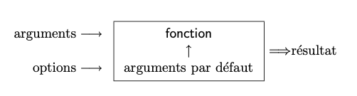

Les **fonctions** prennent en entrée des *objets* de manière optionnelle. On peut également spécifier des **options**. Les options ont des valeurs par défaut. Les fonctions renvoient un **objet** en résultat. Les fonctions sont elle-même des **objets**. Un **opérateur** fait référence aux opérateurs mathématiques, tels que `+` qui ne sont pas invoqués avec des parenthèses.

Exemple: la fonction **ls** permet de lister les objets en mémoire:

```r
ls()
```

```
## [1] "x" "y"
```

## Fonction ls

```r
ls(pattern = "x")
```

```
## [1] "x"
```

```r
m <- data.frame(x, y)
```

```r
ls.str()
```

```
## m : 'data.frame':    1 obs. of  2 variables:
##  $ x: num 7.39
##  $ y: num 6.5
## x :  num 7.39
## y :  num 6.5
```

## Aide

**Aide en ligne** pour la fonction *lm* (linear model)

```r
?lm
```

Cet appel ouvre une page d’aide dans l’onglet “help” de RStudio, contenant les sections suivantes:

- **Description**: Description brève
- **Usage**: Pour une fonction, donne le nom avec ses arguments et les éventuelles options (et leurs valeurs par défaut)
- **Arguments**: Liste des arguments de la fonction
- **Details**: Description détaillée
- **Value**: Le type d’objet éventuellement retourné par la fonction ou l’opérateur

## Aide

- **See Also**: D’autres rubriques proches ou similaire
- **Examples**. Des exemples qui peuvent être généralement exécutés

La fonction `example`:

```r
example(ls)
```

```
##
## ls> .Ob <- 1
##
## ls> ls(pattern = "O")
## character(0)
##
## ls> ls(pattern= "O", all.names = TRUE)    # also shows ".[foo]"
## [1] ".Ob"
##
## ls> # shows an empty list because inside myfunc no variables are defined
## ls> myfunc <- function() {ls()}
##
## ls> myfunc()
## character(0)
##
## ls> # define a local variable inside myfunc
## ls> myfunc <- function() {y <- 1; ls()}
##
## ls> myfunc()                # shows "y"
## [1] "y"
```

## Aide

Aide dans les paquets déjà chargés

```r
help("ls")
```

Aide Dans les paquets installés

```r
help("bs", try.all.packages = TRUE)
```

```r
help.start()
```

Recherche d’un terme dans l’aide

```r
help.search("weighted mean")
```

Recherche dans les noms de fonctions

```r
apropos("read")
```

## Données simples

## Données sous R

```r
1
```

```
## [1] 1
```

```r
1.2
```

```
## [1] 1.2
```

```r
1e10
```

```
## [1] 1e+10
```

```r
"Linux"
```

```
## [1] "Linux"
```

## Opérations

```r
1+1
```

```
## [1] 2
```

```r
10*0.5
```

```
## [1] 5
```

```r
10^2
```

```
## [1] 100
```

```r
paste("Linux", " est excellent")
```

```
## [1] "Linux  est excellent"
```

## Représentations des valeurs numériques

```r
n <- 1
x <- 1.3
X <- 2.5e25

n
```

```
## [1] 1
```

```r
x
```

```
## [1] 1.3
```

```r
X
```

```
## [1] 2.5e+25
```

## Représentation des valeurs infinies

```r
x <- 1/0
x
```

```
## [1] Inf
```

```r
exp(x)
```

```
## [1] Inf
```

```r
exp(-x)
```

```
## [1] 0
```

```r
x - x
```

```
## [1] NaN
```

## Représentations des caractères

```r
my_c <- "Ceci est une valeur en mode caractère."
length(my_c)
```

```
## [1] 1
```

```r
nchar(my_c)
```

```
## [1] 38
```

## Caractère d’échappement

Comme en *bash*, on a la notion de caractère d’échappement:

```r
my_c <- "Ceci est un guillemet double: \"."
cat(my_c)
```

```
## Ceci est un guillemet double: ".
```

On peut utiliser aussi des guillemets simples:

```r
my_c <- 'Ceci est un guillemet double: ".'
cat(my_c)
```

```
## Ceci est un guillemet double: ".
```

## Noms de variables à éviter

- Il vaut **éviter l’utilisation de caractères accentués** pour les noms de variable (et ce, quel que soit le langage !)
- Les noms d’objet ne **peuvent pas commencer par un chiffre**.
- R est **sensible à la casse**, donc **truc**, **Truc** et **TRUC** sont trois objets distincts.
- Les noms suivants **sont utilisés par R**, donc à éviter: **c, q, t, C, D, I, diff, length, mean, pi, range, var**.
- Les mots suivants **sont réservés** et il est interdit de les utiliser comme nom d’objet:
  - `break`, `else`, `for`, `function`, `if`, `in`, `next`, `repeat`, `return`, `while`
  - `TRUE`, `FALSE`
  - `Inf`, `NA`, `NaN`, `NULL`
  - `NA_integer_`, `NA_real_`, `NA_complex_`, `NA_character_`
  - `...`, `..1`, `..2`, etc

## **TRUE** et **FALSE**

Les variables T et F sont affectés par défaut à TRUE et FALSE.

```r
T
```

```
## [1] TRUE
```

```r
F
```

```
## [1] FALSE
```

```r
T <- 3 # A NE PAS FAIRE /!\
T
```

```
## [1] 3
```

```r
TRUE <- 3
Error in TRUE <- 3 : membre gauche
de l'assignation
(do_set) incorrect
```

## Fichiers

## Lecture de données d’un fichier

Répertoires de travail

```r
setwd(dir = "/Users/bidaut/data/")
getwd()
```

```
## [1] "/Users/bidaut/data"
```

Lecture de fichiers texte et importation dans l’environnement R

La fonction la plus commune est `read.table`

```r
read.table(file, header = FALSE, sep = "", quote = "\"’", dec = ".", row.names,
           col.names, as.is = FALSE, na.strings = "NA", colClasses = NA, nrows = -1,
          skip = 0, check.names = TRUE, fill = !blank.lines.skip, strip.white = FALSE,
          blank.lines.skip = TRUE, comment.char = "#")
```

## Exemple: un fichier de description d’experimentation RNA-seq

```r
targets <- read.table(file='targets_GSE130657.txt', header = T)
targets
```

```
##                     SRA_ID     GEO_ID CellType Sample
## 1 SRR9005674.trim.fastq.gz GSM3746500     THP0      1
## 2 SRR9005675.trim.fastq.gz GSM3746501     THP0      2
## 3 SRR9005676.trim.fastq.gz GSM3746502     THP0      3
## 4 SRR9005677.trim.fastq.gz GSM3746503        M      1
## 5 SRR9005678.trim.fastq.gz GSM3746504        M      2
## 6 SRR9005679.trim.fastq.gz GSM3746505        M      3
```

## Enregistrement de données dans un fichier

Enregistrement d’un tableau dans un fichier texte délimité.

```r
write.table(x, file = "", append = FALSE, quote = TRUE, sep = " ",
                        eol = "\n", na = "NA", dec = ".", row.names = TRUE,
                        col.names = TRUE, qmethod = c("escape", "double")))
```

Enregistrement d’un objet dans un fichier de type `.RData`.

```r
save(x, y, z, file="xyz.RData")
```

## Générer des données

## Générér des données

Générer une séquence régulière

```r
x <- 1:30
```

Plus de paramètres

```r
seq(1, 5, 0.5)
```

```
## [1] 1.0 1.5 2.0 2.5 3.0 3.5 4.0 4.5 5.0
```

```r
seq(length=9, from=1, to=5)
```

```
## [1] 1.0 1.5 2.0 2.5 3.0 3.5 4.0 4.5 5.0
```

## La fonction `c`

La fonction `c` permet de combiner des éléments pour former un **Vecteur**.

```r
c(1, 3, 12, 15)
```

```
## [1]  1  3 12 15
```

```r
c('a', c(1:3), 12, "test")
```

```
## [1] "a"    "1"    "2"    "3"    "12"   "test"
```

## Répétition d’éléments

```r
rep(1, 30)
```

```
##  [1] 1 1 1 1 1 1 1 1 1 1 1 1 1 1 1 1 1 1 1 1 1 1 1 1 1 1 1 1 1 1
```

Création d’une suite de séquences

```r
sequence(5:4)
```

```
## [1] 1 2 3 4 5 1 2 3 4
```

```r
sequence(c(10, 5))
```

```
##  [1]  1  2  3  4  5  6  7  8  9 10  1  2  3  4  5
```

## Objets de plus grande dimensions (listes, matrices, etc…)

## Créer des objets: Vecteurs

```r
vector(mode = "numeric", 5)
```

```
## [1] 0 0 0 0 0
```

```r
vector(mode = "logical", 5)
```

```
## [1] FALSE FALSE FALSE FALSE FALSE
```

```r
vector(mode = "character", 5)
```

```
## [1] "" "" "" "" ""
```

## Créer des objets: Facteurs

```r
factor(1:3)
```

```
## [1] 1 2 3
## Levels: 1 2 3
```

```r
factor(1:3, levels = 1:5)
```

```
## [1] 1 2 3
## Levels: 1 2 3 4 5
```

```r
factor(1:3, labels=c("A", "B", "C"))
```

```
## [1] A B C
## Levels: A B C
```

```r
factor(1:5, exclude=4)
```

```
## [1] 1    2    3    <NA> 5
## Levels: 1 2 3 5
```

```r
(ff <- factor(1:3, levels = 1:5))
```

```
## [1] 1 2 3
## Levels: 1 2 3 4 5
```

```r
levels(ff)
```

```
## [1] "1" "2" "3" "4" "5"
```

## Créer des objets: Matrices

Une matrice est un vecteur qui possède un argument supplémentaire (*dim*) qui est lui même un vecteur.

```r
matrix(data = NA, nrow = 1, ncol = 1, byrow = FALSE, dimnames = NULL)
```

L’option `dimname` permet de donner des noms aux lignes et colonnes. l’option `byrow` permet de définir le sens de remplissage.

```r
matrix(seq(1:4), nr=2, nc=2)
```

```
##      [,1] [,2]
## [1,]    1    3
## [2,]    2    4
```

```r
matrix(seq(1:4), nr=2, nc=2, byrow = TRUE)
```

```
##      [,1] [,2]
## [1,]    1    2
## [2,]    3    4
```

## Créer des objets: Matrices

On peut aussi créer une matrice à partir d’un vecteur en assignant les valeurs voulues à `dim`.

```r
x <- 1:15
x
```

```
##  [1]  1  2  3  4  5  6  7  8  9 10 11 12 13 14 15
```

```r
dim(x)
```

[output not shown]

```r
dim(x) <- c(5,3)
x
```

```
##      [,1] [,2] [,3]
## [1,]    1    6   11
## [2,]    2    7   12
## [3,]    3    8   13
## [4,]    4    9   14
## [5,]    5   10   15
```

## Tableaux de données : Data frames

Un tableau de données (*Data frame*) peut être créé directement à partir d’un fichier par un appel à `read.table`.

On peut aussi créer un Data frame par assemblage de vecteurs. Les **noms** des objets sont repris dans les colonnes.

```r
x <- 1:4; n <- 10; M <- c(10, 35); y <- 2:4
data.frame(x, n)
```

```
##   x  n
## 1 1 10
## 2 2 10
## 3 3 10
## 4 4 10
```

## Tableaux de données : Data frames

Si un vecteur est plus court, il sera **recyclé un nombre entier** de fois.

```r
data.frame(x, M)
```

```
##   x  M
## 1 1 10
## 2 2 35
## 3 3 10
## 4 4 35
```

On peut aussi inclure des **Facteurs**.

```r
ff <- factor(1:4); df <- data.frame(x, ff); summary(df)
```

```
##        x        ff
##  Min.   :1.00   1:1
##  1st Qu.:1.75   2:1
##  Median :2.50   3:1
##  Mean   :2.50   4:1
##  3rd Qu.:3.25
##  Max.   :4.00
```

## Créer des objets: Listes

Une liste est créée de la même façon (fonction `list`). Il n’y a pas de contraintes sur le type des objets qui y sont inclus. Les noms des objets ne sont pas repris par défaut mais peuvent être spécifiés.

```r
L1 <- list(x, y); L2 <- list(A=x, B=y)
names(L1)
```

[output not shown]

```r
names(L2)
```

```
## [1] "A" "B"
```

## Conversion d’objets

Il existe plusieurs fonctions de conversions,

- Conversions entre *modes*: **as.numeric**, **as.logical**, **as.character**
- Conversion entre objets: **as.matrix**, **as.data.frame**, **as.list**, **as.ts**:

```r
(fac <- factor(c(1, 10)))
```

```
## [1] 1  10
## Levels: 1 10
```

```r
as.numeric(fac)
```

```
## [1] 1 2
```

## Conversions

```r
fac2 <- factor(c("Male", "Female"))
fac2
```

```
## [1] Male   Female
## Levels: Female Male
```

```r
as.numeric(fac2)
```

```
## [1] 2 1
```

## Extraire des valeurs des objects multidimensionnels

## Accéder aux valeurs des objets

Nous accédons de façon sélective aux éléments d’un objet par l’indexation: `x[3]`

```r
x <- seq(1,5)
x[3]
```

```
## [1] 3
```

```r
x[3] <- 20
x
```

```
## [1]  1  2 20  4  5
```

L’indice lui-même peut être un vecteur:

```r
i <- c(1,3)
x[i]
```

```
## [1]  1 20
```

```r
x <- matrix(1:6, 2,3)
x[, 3]
```

```
## [1] 5 6
```

```r
# Force à renvoyer une matrice

x[,3, drop = FALSE]
```

```
##      [,1]
## [1,]    5
## [2,]    6
```

## Accéder aux valeurs des objets

On peut accéder aux valeurs d’une matrice à l’aide d’une expression de comparaison:

```r
x <- rnorm(10, 1, 4)
x [x>=1] <- 20
x
```

```
##  [1] -1.1201311 20.0000000 -3.0118625 20.0000000 20.0000000 -4.9074832
##  [7] -1.0595318 -0.1307781  0.1187939 -0.6459001
```

Accéder aux valeurs d’une liste: double crochets

```r
x <- 1:3; y <- 1:3; z <- c(1,2,2.9)
li <- list(x, y, z)
li[[1]] # extrait x
```

```
## [1] 1 2 3
```

## Accéder aux valeurs d’une liste

```r
x <- 1:3; y <- 1:3; z <- c(1,2,2.9)
li <- list(x, y, z)
li[[1]][1] # extrait x puis x[1]
```

```
## [1] 1
```

```r
li[[2]][1] # extrait y puis y[1]
```

```
## [1] 1
```

```r
li[[3]][2] # extrait z puis z[2]
```

```
## [1] 2
```

## Accéder aux valeurs des objets avec les noms

```r
x <- matrix(1:4, 2, 2)
colnames(x) = c("a", "b")
rownames(x) = c("c", "d")
x["c", "a"]
```

```
## [1] 1
```

```r
dimnames(x)
```

```
## [[1]]
## [1] "c" "d"
##
## [[2]]
## [1] "a" "b"
```

## Accéder aux valeurs d’un tableau de données (Data frame)

```r
df <- as.data.frame(x)
df
```

```
##   a b
## c 1 3
## d 2 4
```

```r
df$a
```

```
## [1] 1 2
```

## Calcul sur des vecteurs et matrices

## Calcul sur les vecteurs

```r
x <- rnorm(10, 1, 4)
```

Tri

```r
sort(x)
```

```
##  [1] 0.1237387 0.2691357 0.9570236 3.6099530 4.1896520 4.5890956 4.7155764
##  [8] 6.3602299 7.2185892 8.0988833
```

Rang

```r
rank(x)
```

```
##  [1]  5  3  7  1  4  8  2  6  9 10
```

## Calcul sur les vecteurs

Moyenne, variance

```r
mean(x)
```

```
## [1] 4.013188
```

```r
var(x)
```

```
## [1] 7.997861
```

Extraction de valeurs sur test

```r
which(x>3)
```

```
## [1]  1  3  5  6  8  9 10
```

Comparaison

```r
x <- 1:3
y <- 1:10
match(x, y)
```

```
## [1] 1 2 3
```

Extrait les éléments uniques

```r
x <- rep(1:6, 3)
x
```

```
##  [1] 1 2 3 4 5 6 1 2 3 4 5 6 1 2 3 4 5 6
```

```r
unique(x)
```

```
## [1] 1 2 3 4 5 6
```

## Calcul matriciel

*rbind, cbind*

```r
m1 <- matrix(1, nr = 2, nc = 2)
m2 <- matrix(2, nr = 2, nc = 2)
rbind(m1, m2)
```

```
##      [,1] [,2]
## [1,]    1    1
## [2,]    1    1
## [3,]    2    2
## [4,]    2    2
```

```r
cbind(m1, m2)
```

```
##      [,1] [,2] [,3] [,4]
## [1,]    1    1    2    2
## [2,]    1    1    2    2
```

## Produit de matrices

Produit élément par élément (`*`)

```r
m1 * m2
```

```
##      [,1] [,2]
## [1,]    2    2
## [2,]    2    2
```

Produit matriciel (`%*%`)

```r
pm <- rbind(m1, m2) %*% cbind(m1, m2)
pm
```

```
##      [,1] [,2] [,3] [,4]
## [1,]    2    2    4    4
## [2,]    2    2    4    4
## [3,]    4    4    8    8
## [4,]    4    4    8    8
```

Transposition (`t`)

```r
m <- matrix(rep(1:4, 3), 3, 4)
t(m)
```

```
##      [,1] [,2] [,3]
## [1,]    1    2    3
## [2,]    4    1    2
## [3,]    3    4    1
## [4,]    2    3    4
```

## Utilisation plus avancée et formalisation

## Opérateurs

Il y a trois principaux types d’opérateurs dans R:

- Opérateurs arithmétiques: `+`, `-`, `*`, `/`, `^`, `%%` (modulo), `%/%` (Division entière)
- Opérateurs de comparaison: `<` `>` `<=` `>=` `==` `!=`
- Opérateurs logiques: `!` (non), `&` ou `&&` (et), `|` ou `||` (ou), `xor(x,y)` (ou exclusif)

```r
x <- 0.5
0 < x & x < 1
```

```
## [1] TRUE
```

```r
x <- 1:3; y <- 1:3; z <- c(1,2,2.9)
x == y
```

```
## [1] TRUE TRUE TRUE
```

## Objets et attributs

Considérons une variable qui prendrait les valeurs 1,2 ou 3.

- Est-ce que cette variable est un entier ?
- Est ce que cette variable est le codage d’une variable catégorielle ?

Deux attributs intrinsèque: *mode* et *longueur*:

- Le **Mode**: `numeric`, `character`, `complex`, `logical`, `function`, `list`, `expression`
- La **Longueur**: Un entier correspondant au nombre d’éléments de l’objet

*List* ou *expression* sont des objets *récursifs* (Qui peuvent contenir eux même d’autres objets).

## Un peu d’exploration sur ces attributs

```r
x <- 1
mode(x)
```

```
## [1] "numeric"
```

```r
A <- "Linux"; compar <- TRUE; z <- 1i
mode(A); mode(compar); mode(z)
```

```
## [1] "character"
```

```
## [1] "logical"
```

```
## [1] "complex"
```

## Voir le type de données avec `str`

```r
str(A); str(compar); str(z)
```

```
##  chr "Linux"
```

```
##  logi TRUE
```

```
##  cplx 0+1i
```

## Stratégie de travail

Une fois notre session terminée, on peut quitter R et sauver notre session

```bash
q()
Save workspace image? [y/n/c]: y
```

Des fichiers `.RData` (contenant les **objets R** créés) et `.Rhistory` sont créés.

Le problème de cette approche est que nous ne **conservons pas** les instructions qui ont permis de créer les fichiers utilisés **de manière organisée**.

Il est important de consolider le code qui permet de créer les objets en conservant les instructions dans un *script*.

Sous R, on peut créer des scripts en enregistrant des instructions dans des fichiers portant l’extension `.R`.

## Programmation

On peut mettre les commandes dans un fichier **RScript**, ce qui permet de les exécuter plus tard. Ce type de fichier porte l’extension *.R*.

On peut directement en créer un dans RStudio, puis l’exécuter soit **pas à pas (commande ALT-Entrée)**, soit dans son intégralité dans la **console**.

Pour structurer son code on doit:

- le commenter à l’aide du caractère `#`

```r
# Ceci est un commentaire
```

- Utiliser des fonctions

```r
my_square_function <- function(x) {
  return(x*x)
}
my_square_function(2)
```

```
## [1] 4
```

## Graphiques

## Graphique simple

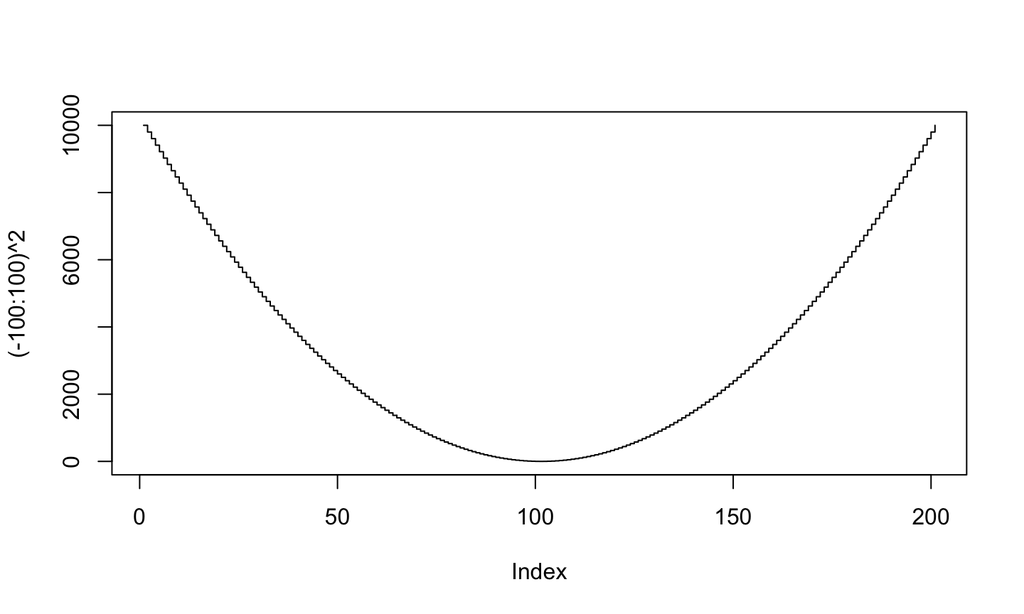

```r
plot((-100:100)^2, type = "s") # s = stair steps
```

## Plot d’une fonction

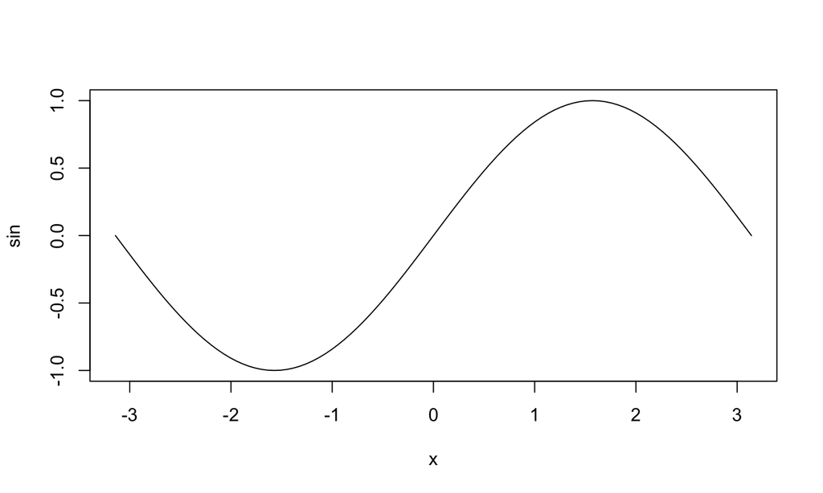

```r
plot(sin, -pi, pi) # ou curve(sin(x), -pi, pi)
```

## Histogramme

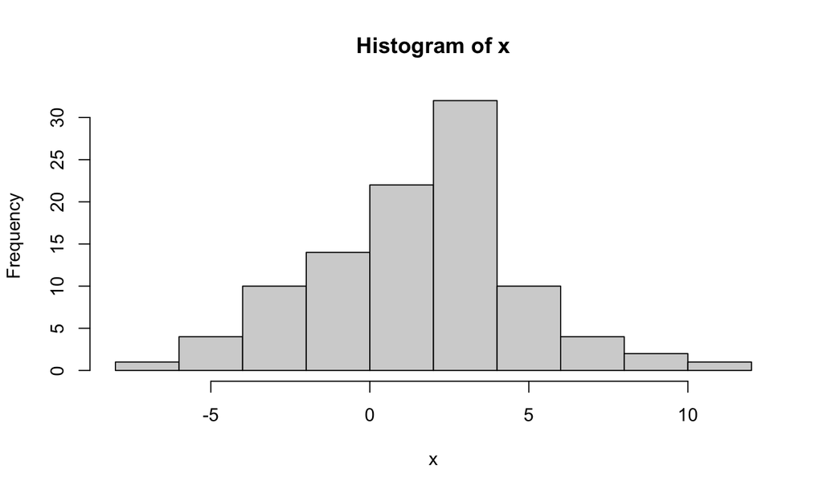

```r
x <- rnorm(100, 1, 3)
hist(x)
```

## Avancé

## Génération de niveaux (**gl**)

`gl(k,n)` génère **k** niveaux de données dans un facteur répétées **n** fois.

```r
gl(3,5)
```

```
##  [1] 1 1 1 1 1 2 2 2 2 2 3 3 3 3 3
## Levels: 1 2 3
```

```r
gl(3,5, length = 30)
```

```
##  [1] 1 1 1 1 1 2 2 2 2 2 3 3 3 3 3 1 1 1 1 1 2 2 2 2 2 3 3 3 3 3
## Levels: 1 2 3
```

```r
gl(2,6, label=c("Male", "Femelle"))
```

```
##  [1] Male    Male    Male    Male    Male    Male    Femelle Femelle Femelle
## [10] Femelle Femelle Femelle
## Levels: Male Femelle
```

## Création d’un tableau avec toutes les combinaisons

Fonction `expand.grid`:

```r
expand.grid(h=c(60,80), w=c(100, 300), sex=c("Male", "Female"))
```

```
##    h   w    sex
## 1 60 100   Male
## 2 80 100   Male
## 3 60 300   Male
## 4 80 300   Male
## 5 60 100 Female
## 6 80 100 Female
## 7 60 300 Female
## 8 80 300 Female
```

## Générer des données aléatoires

R permet de générer des données aléatoires à partir d’un grand nombre de lois de densité de probabilités.

[output not shown]

## Générer des données aléatoires

Par exemple, pour obtenir les valeurs critiques au seuil de 5% pour un test bilatéral suivant une loi normale:

```r
qnorm(0.025)
```

```
## [1] -1.959964
```

```r
qnorm(0.975)
```

```
## [1] 1.959964
```

## Créer des objets: Séries temporelles

La fonction `ts` va créer une série temporelle à partir d’un vecteur (série temporelle simple) ou d’une matrice (série temporelle multiple).

```r
ts(1:10, start = 1959)
```

```
## Time Series:
## Start = 1959
## End = 1968
## Frequency = 1
##  [1]  1  2  3  4  5  6  7  8  9 10
```

```r
ts(1:47, frequency = 12, start = c(1959, 2))
```

```
##      Jan Feb Mar Apr May Jun Jul Aug Sep Oct Nov Dec
## 1959       1   2   3   4   5   6   7   8   9  10  11
## 1960  12  13  14  15  16  17  18  19  20  21  22  23
## 1961  24  25  26  27  28  29  30  31  32  33  34  35
## 1962  36  37  38  39  40  41  42  43  44  45  46  47
```

## Créer des objets: Séries temporelles

```r
ts(1:10, frequency = 4, start = c(1959,2))
```

```
##      Qtr1 Qtr2 Qtr3 Qtr4
## 1959         1    2    3
## 1960    4    5    6    7
## 1961    8    9   10
```

```r
ts(matrix(rpois(36, 5), 6, 3), start = c(1961,1), frequency = 12)
```

```
##          Series 1 Series 2 Series 3
## Jan 1961        2        6        7
## Feb 1961        1        3        2
## Mar 1961        5        7        5
## Apr 1961        4        3        5
## May 1961        5        8        8
## Jun 1961        4        5        7
```

## Créer des objets: Expression

Toutes les commandes valides sont des expressions. Or, il est possible en R de stocker une expression dans un objet sans l’évaluer (fonction `expression`). Ces objets représentent des expressions littérales que l’on peut ensuite évaluer avec la fonction `eval`.

```r
x <- 3; y <- 2.5; z <- 1
exp1 <- expression(x / (y + exp(z)))
exp1
```

```
## expression(x/(y + exp(z)))
```

```r
eval(exp1)
```

```
## [1] 0.5749019
```

```r
D(exp1, "z") # Calcul de la dérivée partielle d'exp1 en z
```

```
## -(x * exp(z)/(y + exp(z))^2)
```

## Comparaison de valeurs numériques

```r
identical(x,y)
```

```
## [1] FALSE
```

```r
all.equal(x, z)
```

```
## [1] "Mean relative difference: 0.6666667"
```

```r
0.9 == (1.1 - 0.2)
```

```
## [1] FALSE
```

```r
identical(0.9, 1.1 - 0.2)
```

```
## [1] FALSE
```

```r
all.equal(0.9, 1.1 - 0.2)
```

```
## [1] TRUE
```

```r
all.equal(0.9, 1.1 - 0.2, tolerance = 1e-16)
```

```
## [1] "Mean relative difference: 1.233581e-16"
```

## Ressources

- *Introduction à la programmation en R* par *Vincent Goulet*: https://cran.r-project.org/doc/contrib/Goulet_introduction_programmation_R.pdf
- *R pour les débutants*, par *Emmanuel Paradis*: https://cran.r-project.org/doc/contrib/Paradis-rdebuts_fr.pdf

## Bioconductor

## Bioconductor

**Bioconductor** possède son propre dépôt et sa propre fonction pour installer des paquets.

https://www.bioconductor.org/install/

Installation sous R:

```r
if (!requireNamespace("BiocManager", quietly = TRUE))
    install.packages("BiocManager")
BiocManager::install()
```

Paquets disponibles: https://www.bioconductor.org/packages/release/BiocViews.html#___Software

## Recherche et installation de packages Bioconductor

Exemple: le paquet **edgeR**:

https://www.bioconductor.org/packages/release/bioc/html/edgeR.html

Installation:

```r
if (!requireNamespace("BiocManager", quietly = TRUE))
    install.packages("BiocManager")

BiocManager::install("edgeR")
```

Vignette:

```r
browseVignettes("edgeR")
```

## Data sheets:

- DataSheet **Base R**: https://github.com/rstudio/cheatsheets/blob/main/base-r.pdf
- DataSheet **RStudio:**: https://github.com/rstudio/cheatsheets/blob/main/rstudio-ide.pdf
- DataSheet **“tout”**: https://github.com/rstudio/cheatsheets/tree/main

## Licence

Cette œuvre est mise à disposition selon les termes de la [Licence Creative Commons:](http://creativecommons.org/licenses/by-nc-nd/4.0/)  
Attribution - Pas d’Utilisation Commerciale - Pas de Modification 4.0 International (CC BY-NC-ND 4.0).